# QBS 181 Final project

Hellarine Wu

2026-11-11

# Insert packages

```r
library(readxl)
library(dplyr)
library(stringr)
library(tidyr)
```

```r
library(ggplot2)
library(tigris)
library(sf)
```

# Data Cleaning

```r
#step 1, insert datasets. We will use the county level data as the analysis file.
natality_raw <- read_excel(
  "/Users/hellarinewu/Desktop/QBS 181 Data Wrangling/cleaned_data_10.29.26.xlsx",
  sheet = "county level data",
  col_types = "text"
)
dim(natality_raw)
```

```
## [1] 627  20
```

```r
names(natality_raw)
```

```
##  [1] "Census_Region_of_Residence"
##  [2] "Census_Division_of_Residence"
##  [3] "State_of_Residence"
##  [4] "State_of_Residence_Code"
##  [5] "County_of_Residence"
##  [6] "County_of_Residence_Code"
##  [7] "Births"
##  [8] "Total_Population"
##  [9] "Birth_Rate"
## [10] "Female_Population"
## [11] "Fertility_Rate"
## [12] "Percentage_of_Total_Births"
## [13] "Average_Age_of_Mother"
## [14] "Average_OE_Gestational_Age"
## [15] "Average LMP Gestational Age (weeks)"
## [16] "Average Birth Weight (grams)"
## [17] "Average Pre-pregnancy BMI"
## [18] "Average Number of Prenatal Visits"
## [19] "Average Interval Since Last Live Birth (months)"
## [20] "Average Interval Since Last Other Pregnancy Outcome (months)"
```

```r
head(natality_raw)
```

```
## # A tibble: 6 × 20
##   Census_Region_of_Residence Census_Division_of_Residence State_of_Residence
##   <chr>                      <chr>                        <chr>
## 1 1                          1                            Connecticut
## 2 1                          1                            Connecticut
## 3 1                          1                            Connecticut
## 4 1                          1                            Connecticut
## 5 1                          1                            Connecticut
## 6 1                          1                            Connecticut
## # ℹ 17 more variables: State_of_Residence_Code <chr>,
## #   County_of_Residence <chr>, County_of_Residence_Code <chr>, Births <chr>,
## #   Total_Population <chr>, Birth_Rate <chr>, Female_Population <chr>,
## #   Fertility_Rate <chr>, Percentage_of_Total_Births <chr>,
## #   Average_Age_of_Mother <chr>, Average_OE_Gestational_Age <chr>,
## #   `Average LMP Gestational Age (weeks)` <chr>,
## #   `Average Birth Weight (grams)` <chr>, `Average Pre-pregnancy BMI` <chr>, …
```

```r
rucc_raw <- read_excel(
  "/Users/hellarinewu/Desktop/QBS 181 Data Wrangling/Ruralurbancontinuumcodes2023.xlsx",
  sheet = "Rural-urban Continuum Code 2023",
  col_types = "text"
)
dim(rucc_raw)
```

```
## [1] 3235    6
```

```r
names(rucc_raw)
```

```
## [1] "FIPS"            "State"           "County_Name"     "Population_2020"
## [5] "RUCC_2023"       "Description"
```

```r
head(rucc_raw)
```

```
## # A tibble: 6 × 6
##   FIPS  State County_Name    Population_2020 RUCC_2023 Description
##   <chr> <chr> <chr>          <chr>           <chr>     <chr>
## 1 01001 AL    Autauga County 58805           2         Metro - Counties in metr…
## 2 01003 AL    Baldwin County 231767          3         Metro - Counties in metr…
## 3 01005 AL    Barbour County 25223           6         Nonmetro - Urban populat…
## 4 01007 AL    Bibb County    22293           1         Metro - Counties in metr…
## 5 01009 AL    Blount County  59134           1         Metro - Counties in metr…
## 6 01011 AL    Bullock County 10357           8         Nonmetro - Urban populat…
```

```r
#step 2, check the data structure on 2 dataset before we combine them, and make sure all the variables are in the correct structure
glimpse(natality_raw)
```

```
## Rows: 627
## Columns: 20
## $ Census_Region_of_Residence                                     <chr> "1", "1…
## $ Census_Division_of_Residence                                   <chr> "1", "1…
## $ State_of_Residence                                             <chr> "Connec…
## $ State_of_Residence_Code                                        <chr> "9", "9…
## $ County_of_Residence                                            <chr> "Fairfi…
## $ County_of_Residence_Code                                       <chr> "09001"…
## $ Births                                                         <chr> "10053"…
## $ Total_Population                                               <chr> NA, NA,…
## $ Birth_Rate                                                     <chr> NA, NA,…
## $ Female_Population                                              <chr> NA, NA,…
## $ Fertility_Rate                                                 <chr> NA, NA,…
## $ Percentage_of_Total_Births                                     <chr> "2.7699…
## $ Average_Age_of_Mother                                          <chr> "32.271…
## $ Average_OE_Gestational_Age                                     <chr> "38.5",…
## $ `Average LMP Gestational Age (weeks)`                          <chr> "38.668…
## $ `Average Birth Weight (grams)`                                 <chr> "3291.4…
## $ `Average Pre-pregnancy BMI`                                    <chr> "26.216…
## $ `Average Number of Prenatal Visits`                            <chr> "12.207…
## $ `Average Interval Since Last Live Birth (months)`              <chr> "52.317…
## $ `Average Interval Since Last Other Pregnancy Outcome (months)` <chr> "48.32"…
```

```r
glimpse(rucc_raw)
```

```
## Rows: 3,235
## Columns: 6
## $ FIPS            <chr> "01001", "01003", "01005", "01007", "01009", "01011", …
## $ State           <chr> "AL", "AL", "AL", "AL", "AL", "AL", "AL", "AL", "AL", …
## $ County_Name     <chr> "Autauga County", "Baldwin County", "Barbour County", …
## $ Population_2020 <chr> "58805", "231767", "25223", "22293", "59134", "10357",…
## $ RUCC_2023       <chr> "2", "3", "6", "1", "1", "8", "6", "3", "6", "8", "1",…
## $ Description     <chr> "Metro - Counties in metro areas of 250,000 to 1 milli…
```

```r
natality <- natality_raw
rucc <- rucc_raw

## loop1 for natality
numeric_columns <- names(
  dplyr::select(natality, Births:dplyr::last_col())
)

for (column in names(natality)) {

  if (column %in% numeric_columns) {
    natality[[column]] <- as.numeric(natality[[column]])

  } else if (column == "Census_Region_of_Residence") {
    natality[[column]] <- factor(
      natality[[column]],
      levels = as.character(1:4),
      labels = c("Northeast", "Midwest", "South", "West")
    )

  } else if (column == "Census_Division_of_Residence") {
    natality[[column]] <- factor(
      natality[[column]],
      levels = as.character(1:9),
      labels = c(
        "New England", "Middle Atlantic",
        "East North Central", "West North Central",
        "South Atlantic", "East South Central",
        "West South Central", "Mountain", "Pacific"
      )
    )
  }
}

## loop 2 for rucc
for (column in names(rucc)) {

  if (column == "Population_2020") {
    rucc[[column]] <- as.numeric(rucc[[column]])

  } else if (column == "RUCC_2023") {
    rucc[[column]] <- factor(
      rucc[[column]],
      levels = as.character(1:9)
    )
  }
}
rucc <- rucc %>%
  mutate(
    metro_status = factor(
      case_when(
        as.character(RUCC_2023) %in% as.character(1:3) ~
          "Metropolitan",
        as.character(RUCC_2023) %in% as.character(4:9) ~
          "Nonmetropolitan",
        TRUE ~ NA_character_
      ),
      levels = c("Metropolitan", "Nonmetropolitan")
    )
  )

glimpse(natality)
```

```
## Rows: 627
## Columns: 20
## $ Census_Region_of_Residence                                     <fct> Northea…
## $ Census_Division_of_Residence                                   <fct> New Eng…
## $ State_of_Residence                                             <chr> "Connec…
## $ State_of_Residence_Code                                        <chr> "9", "9…
## $ County_of_Residence                                            <chr> "Fairfi…
## $ County_of_Residence_Code                                       <chr> "09001"…
## $ Births                                                         <dbl> 10053, …
## $ Total_Population                                               <dbl> NA, NA,…
## $ Birth_Rate                                                     <dbl> NA, NA,…
## $ Female_Population                                              <dbl> NA, NA,…
## $ Fertility_Rate                                                 <dbl> NA, NA,…
## $ Percentage_of_Total_Births                                     <dbl> 0.00277…
## $ Average_Age_of_Mother                                          <dbl> 32.271,…
## $ Average_OE_Gestational_Age                                     <dbl> 38.500,…
## $ `Average LMP Gestational Age (weeks)`                          <dbl> 38.669,…
## $ `Average Birth Weight (grams)`                                 <dbl> 3291.44…
## $ `Average Pre-pregnancy BMI`                                    <dbl> 26.217,…
## $ `Average Number of Prenatal Visits`                            <dbl> 12.207,…
## $ `Average Interval Since Last Live Birth (months)`              <dbl> 52.318,…
## $ `Average Interval Since Last Other Pregnancy Outcome (months)` <dbl> 48.320,…
```

```r
glimpse(rucc)
```

```
## Rows: 3,235
## Columns: 7
## $ FIPS            <chr> "01001", "01003", "01005", "01007", "01009", "01011", …
## $ State           <chr> "AL", "AL", "AL", "AL", "AL", "AL", "AL", "AL", "AL", …
## $ County_Name     <chr> "Autauga County", "Baldwin County", "Barbour County", …
## $ Population_2020 <dbl> 58805, 231767, 25223, 22293, 59134, 10357, 19051, 1164…
## $ RUCC_2023       <fct> 2, 3, 6, 1, 1, 8, 6, 3, 6, 8, 1, 9, 9, 9, 8, 4, 3, 9, …
## $ Description     <chr> "Metro - Counties in metro areas of 250,000 to 1 milli…
## $ metro_status    <fct> Metropolitan, Metropolitan, Nonmetropolitan, Metropoli…
```

```r
table(rucc$metro_status, useNA = "ifany")
```

```
##
##    Metropolitan Nonmetropolitan            <NA>
##            1252            1981               2
```

```r
### look at 2 NAs
rucc_missing <- rucc_raw %>%
  filter(
    FIPS %in% rucc$FIPS[is.na(rucc$metro_status)]
  ) %>%
  select(FIPS, State, County_Name, RUCC_2023, Description)

print(rucc_missing, n = Inf, width = Inf)
```

```
## # A tibble: 2 × 5
##   FIPS  State County_Name   RUCC_2023 Description
##   <chr> <chr> <chr>         <chr>     <chr>
## 1 60030 AS    Rose Island   <NA>      Not Applicable
## 2 60040 AS    Swains Island <NA>      Not Applicable
```

```r
sapply(natality, class)
```

```
##                                   Census_Region_of_Residence
##                                                     "factor"
##                                 Census_Division_of_Residence
##                                                     "factor"
##                                           State_of_Residence
##                                                  "character"
##                                      State_of_Residence_Code
##                                                  "character"
##                                          County_of_Residence
##                                                  "character"
##                                     County_of_Residence_Code
##                                                  "character"
##                                                       Births
##                                                    "numeric"
##                                             Total_Population
##                                                    "numeric"
##                                                   Birth_Rate
##                                                    "numeric"
##                                            Female_Population
##                                                    "numeric"
##                                               Fertility_Rate
##                                                    "numeric"
##                                   Percentage_of_Total_Births
##                                                    "numeric"
##                                        Average_Age_of_Mother
##                                                    "numeric"
##                                   Average_OE_Gestational_Age
##                                                    "numeric"
##                          Average LMP Gestational Age (weeks)
##                                                    "numeric"
##                                 Average Birth Weight (grams)
##                                                    "numeric"
##                                    Average Pre-pregnancy BMI
##                                                    "numeric"
##                            Average Number of Prenatal Visits
##                                                    "numeric"
##              Average Interval Since Last Live Birth (months)
##                                                    "numeric"
## Average Interval Since Last Other Pregnancy Outcome (months)
##                                                    "numeric"
```

```r
#step 3, standardize the FIPS identifiers
natality <- natality %>%
  mutate(
    state_fips = str_pad(
      str_trim(State_of_Residence_Code),
      width = 2, side = "left", pad = "0"
    ),
    fips = str_pad(
      str_trim(County_of_Residence_Code),
      width = 5, side = "left", pad = "0"
    )
  )

rucc <- rucc %>%
  mutate(
    fips = str_pad(
      str_trim(FIPS),
      width = 5, side = "left", pad = "0"
    )
  )

## data validation: check natality codes for missing values, incorrect formate or state code mismatches
fips_issues <- natality %>%
  filter(
    is.na(fips) |
      is.na(state_fips) |
      !str_detect(fips, "^[0-9]{5}$") |
      !str_detect(state_fips, "^[0-9]{2}$") |
      str_sub(fips, 1, 2) != state_fips
  ) %>%
  select(
    State_of_Residence,
    County_of_Residence,
    County_of_Residence_Code,
    state_fips,
    fips
  )

print(fips_issues, n = Inf, width = Inf)
```

```
## # A tibble: 1 × 5
##   State_of_Residence County_of_Residence County_of_Residence_Code state_fips
##   <chr>              <chr>               <chr>                    <chr>
## 1 Arkansas           Benton County, AR   5                        05
##   fips
##   <chr>
## 1 00005
```

```r
natality <- natality %>%
  mutate(
    fips = case_when(
      State_of_Residence == "Arkansas" &
        County_of_Residence == "Benton County, AR" &
        fips == "00005" ~ "05007",
      TRUE ~ fips
    )
  )
natality %>%
  filter(
    State_of_Residence == "Arkansas",
    County_of_Residence == "Benton County, AR"
  ) %>%
  select(
    County_of_Residence,
    County_of_Residence_Code,
    state_fips,
    fips
  )
```

```
## # A tibble: 1 × 4
##   County_of_Residence County_of_Residence_Code state_fips fips
##   <chr>               <chr>                    <chr>      <chr>
## 1 Benton County, AR   5                        05         05007
```

```r
natality <- natality %>%
  mutate(
    is_pooled = str_detect(
      County_of_Residence,
      "^Unidentified Counties"
    )
  )
print(natality %>% count(is_pooled))
```

```
## # A tibble: 2 × 2
##   is_pooled     n
##   <lgl>     <int>
## 1 FALSE       578
## 2 TRUE         49
```

```r
natality_pooled <- natality %>%
  filter(is_pooled)
natality_counties <- natality %>%
  filter(!is_pooled)
nrow(natality_pooled)
```

```
## [1] 49
```

```r
nrow(natality_counties)
```

```
## [1] 578
```

```r
analysis_vars <- c(
  "fips",
  "State_of_Residence",
  "County_of_Residence",
  "Census_Region_of_Residence",
  "Births",
  "Average_Age_of_Mother",
  "Average Pre-pregnancy BMI",
  "Average Birth Weight (grams)",
  "Average_OE_Gestational_Age",
  "Average Number of Prenatal Visits"
)

### check for missing variables
missing_summary <- data.frame(
  variable = analysis_vars,
  n_missing = colSums(
    is.na(natality_counties[analysis_vars])
  ),
  row.names = NULL
)

print(missing_summary, row.names = FALSE)
```

```
##                           variable n_missing
##                               fips         0
##                 State_of_Residence         0
##                County_of_Residence         0
##         Census_Region_of_Residence         0
##                             Births         0
##              Average_Age_of_Mother         0
##          Average Pre-pregnancy BMI         0
##       Average Birth Weight (grams)         0
##         Average_OE_Gestational_Age         0
##  Average Number of Prenatal Visits         0
```

```r
## now we check which natality counties lack a matching rucc FIPS code
unmatched_counties <- natality_counties %>%
  anti_join(rucc, by = "fips") %>%
  select(
    State_of_Residence,
    County_of_Residence,
    fips
  )

print(unmatched_counties, n = Inf)
```

```
## # A tibble: 8 × 3
##   State_of_Residence County_of_Residence   fips
##   <chr>              <chr>                 <chr>
## 1 Connecticut        Fairfield County, CT  09001
## 2 Connecticut        Hartford County, CT   09003
## 3 Connecticut        Litchfield County, CT 09005
## 4 Connecticut        Middlesex County, CT  09007
## 5 Connecticut        New Haven County, CT  09009
## 6 Connecticut        New London County, CT 09011
## 7 Connecticut        Tolland County, CT    09013
## 8 Connecticut        Windham County, CT    09015
```

```r
nrow(unmatched_counties)
```

```
## [1] 8
```

```r
#step 4, join rucc onto the natality data
natality_linked <- natality_counties %>%
  left_join(
    rucc %>%
      select(fips, RUCC_2023, metro_status),
    by = "fips"
  )
nrow(natality_linked)
```

```
## [1] 578
```

```r
print(
  natality_linked %>%
    count(metro_status, .drop = FALSE)
)
```

```
## # A tibble: 3 × 2
##   metro_status        n
##   <fct>           <int>
## 1 Metropolitan      550
## 2 Nonmetropolitan    20
## 3 <NA>                8
```

```r
natality_linked <- natality_linked %>%
  mutate(
    RUCC_2023 = factor(
      as.character(RUCC_2023),
      levels = as.character(1:9)
    )
  )

print(
  natality_linked %>%
    count(RUCC_2023, .drop = FALSE),
  n = Inf
)
```

```
## # A tibble: 10 × 2
##    RUCC_2023     n
##    <fct>     <int>
##  1 1           244
##  2 2           177
##  3 3           129
##  4 4            18
##  5 5             2
##  6 6             0
##  7 7             0
##  8 8             0
##  9 9             0
## 10 <NA>          8
```

```r
#step 5 create our analysis datafile
## make sure the variables are in the correct range before analyse the data
measurement_vars <- c(
  "Births",
  "Average_Age_of_Mother",
  "Average Pre-pregnancy BMI",
  "Average Birth Weight (grams)",
  "Average_OE_Gestational_Age",
  "Average Number of Prenatal Visits"
)

range_summary <- data.frame(
  variable = measurement_vars,
  minimum = sapply(
    natality_linked[measurement_vars],
    min,
    na.rm = TRUE
  ),
  maximum = sapply(
    natality_linked[measurement_vars],
    max,
    na.rm = TRUE
  ),
  row.names = NULL
)

print(range_summary, row.names = FALSE)
```

```
##                           variable  minimum   maximum
##                             Births  613.000 90507.000
##              Average_Age_of_Mother   26.801    33.624
##          Average Pre-pregnancy BMI   24.711    30.280
##       Average Birth Weight (grams) 2994.377  3405.876
##         Average_OE_Gestational_Age   37.447    38.841
##  Average Number of Prenatal Visits    8.267    14.350
```

```r
analysis_data <- natality_linked %>%
  select(
    county_fips = fips,
    state_fips,
    state = State_of_Residence,
    county = County_of_Residence,
    region = Census_Region_of_Residence,
    division = Census_Division_of_Residence,
    births = Births,
    maternal_age = Average_Age_of_Mother,
    prepregnancy_bmi = `Average Pre-pregnancy BMI`,
    birth_weight_g = `Average Birth Weight (grams)`,
    gestational_age_oe_weeks = Average_OE_Gestational_Age,
    prenatal_visits = `Average Number of Prenatal Visits`,
    rucc_2023 = RUCC_2023,
    metro_status
  )

glimpse(analysis_data)
```

```
## Rows: 578
## Columns: 14
## $ county_fips              <chr> "09001", "09003", "09005", "09007", "09009", …
## $ state_fips               <chr> "09", "09", "09", "09", "09", "09", "09", "09…
## $ state                    <chr> "Connecticut", "Connecticut", "Connecticut", …
## $ county                   <chr> "Fairfield County, CT", "Hartford County, CT"…
## $ region                   <fct> Northeast, Northeast, Northeast, Northeast, N…
## $ division                 <fct> New England, New England, New England, New En…
## $ births                   <dbl> 10053, 8780, 1430, 1361, 8366, 2466, 1154, 98…
## $ maternal_age             <dbl> 32.271, 30.958, 31.248, 31.827, 30.898, 30.32…
## $ prepregnancy_bmi         <dbl> 26.217, 27.870, 27.818, 27.467, 28.173, 27.86…
## $ birth_weight_g           <dbl> 3291.441, 3240.419, 3299.929, 3314.736, 3262.…
## $ gestational_age_oe_weeks <dbl> 38.500, 38.277, 38.352, 38.405, 38.393, 38.51…
## $ prenatal_visits          <dbl> 12.207, 11.973, 12.335, 12.158, 12.158, 12.34…
## $ rucc_2023                <fct> NA, NA, NA, NA, NA, NA, NA, NA, 3, 2, 4, 3, 2…
## $ metro_status             <fct> NA, NA, NA, NA, NA, NA, NA, NA, Metropolitan,…
```

```r
core_vars <- setdiff(
  names(analysis_data),
  c("rucc_2023", "metro_status")
)

final_checks <- data.frame(
  counties = nrow(analysis_data),
  unique_fips = n_distinct(analysis_data$county_fips),
  missing_core_values = sum(is.na(analysis_data[core_vars])),
  missing_rucc = sum(is.na(analysis_data$rucc_2023)),
  missing_metro = sum(is.na(analysis_data$metro_status)),
  missing_rurality_outside_CT = sum(
    analysis_data$state != "Connecticut" &
      (
        is.na(analysis_data$rucc_2023) |
          is.na(analysis_data$metro_status)
      )
  ),
  pooled_rows = sum(
    str_detect(analysis_data$county, "^Unidentified Counties")
  )
)

print(final_checks, row.names = FALSE)
```

```
##  counties unique_fips missing_core_values missing_rucc missing_metro
##       578         578                   0            8             8
##  missing_rurality_outside_CT pooled_rows
##                            0           0
```

```r
#save the analysis file in rds format
output_file <- paste0(
  "/Users/hellarinewu/Desktop/QBS 181 Data Wrangling/",
  "analysis_data_2024_rucc2023.rds"
)
```

# Aim 1. Describe geographic differences in maternal characteristics and birth outcomes among individually identified US counties in 2024

## 1.1: Compare county averages for maternal age, prepregnancy BMI, birth weight, and obstetric-estimate gestational age across the four Census regions using summary tables and boxplots. Examine metropolitan–nonmetropolitan differences using the 2023 rucc where sufficient counties are available

```r
# region table summary
regional_summary <- analysis_data %>%
  select(
    region,
    maternal_age,
    prepregnancy_bmi,
    birth_weight_g,
    gestational_age_oe_weeks
  ) %>%
  pivot_longer(
    cols = -region,
    names_to = "measure",
    values_to = "county_average"
  ) %>%
  group_by(region, measure) %>%
  summarise(
    n_counties = n(),
    mean = mean(county_average),
    sd = sd(county_average),
    median = median(county_average),
    iqr = IQR(county_average),
    .groups = "drop"
  )

print(regional_summary, n = Inf, width = Inf)
```

```
## # A tibble: 16 × 7
##    region    measure                  n_counties   mean     sd median    iqr
##    <fct>     <chr>                         <int>  <dbl>  <dbl>  <dbl>  <dbl>
##  1 Northeast birth_weight_g                  110 3274.  47.7   3268.  64.0
##  2 Northeast gestational_age_oe_weeks        110   38.4  0.143   38.4  0.173
##  3 Northeast maternal_age                    110   30.6  1.29    30.7  1.83
##  4 Northeast prepregnancy_bmi                110   27.8  1.02    28.0  1.31
##  5 Midwest   birth_weight_g                  137 3267.  52.3   3276.  72.1
##  6 Midwest   gestational_age_oe_weeks        137   38.3  0.157   38.3  0.205
##  7 Midwest   maternal_age                    137   29.4  1.06    29.3  1.41
##  8 Midwest   prepregnancy_bmi                137   28.3  0.728   28.4  0.951
##  9 South     birth_weight_g                  232 3222.  60.0   3231.  73.2
## 10 South     gestational_age_oe_weeks        232   38.2  0.192   38.2  0.218
## 11 South     maternal_age                    232   29.2  1.21    29.1  1.63
## 12 South     prepregnancy_bmi                232   28.2  0.915   28.2  1.23
## 13 West      birth_weight_g                   99 3268.  61.6   3275.  88.7
## 14 West      gestational_age_oe_weeks         99   38.5  0.140   38.5  0.209
## 15 West      maternal_age                     99   29.9  1.29    29.6  1.93
## 16 West      prepregnancy_bmi                 99   27.7  1.09    27.8  1.46
```

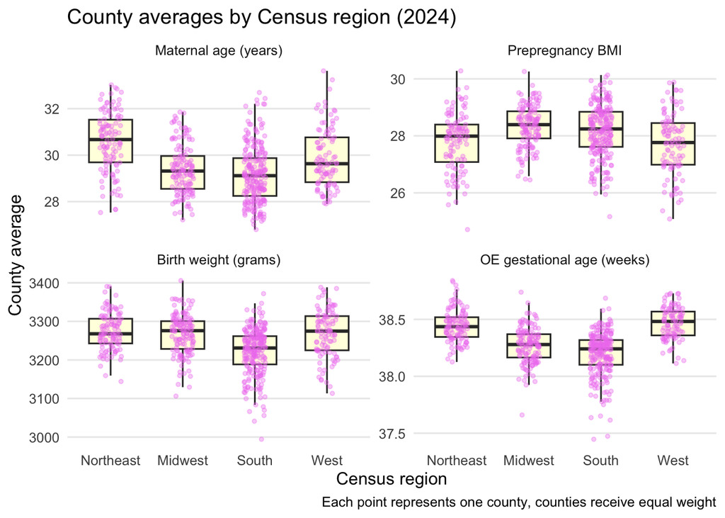

```r
# regional boxplots
aim1_long <- analysis_data %>%
  select(
    region,
    maternal_age,
    prepregnancy_bmi,
    birth_weight_g,
    gestational_age_oe_weeks
  ) %>%
  pivot_longer(
    cols = -region,
    names_to = "measure",
    values_to = "county_average"
  ) %>%
  mutate(
    measure = factor(
      measure,
      levels = c(
        "maternal_age",
        "prepregnancy_bmi",
        "birth_weight_g",
        "gestational_age_oe_weeks"
      ),
      labels = c(
        "Maternal age (years)",
        "Prepregnancy BMI",
        "Birth weight (grams)",
        "OE gestational age (weeks)"
      )
    )
  )


regional_plot <- ggplot(
  aim1_long,
  aes(x = region, y = county_average)
) +
  geom_boxplot(
    width = 0.6,
    fill = "lightyellow",
    outlier.shape = NA
  ) +
  geom_point(
    position = position_jitter(
      width = 0.15,
      height = 0,
      seed = 181
    ),
    alpha = 0.35,
    size = 1,
    color = "violet"
  ) +
  facet_wrap(
    ~ measure,
    scales = "free_y",
    ncol = 2
  ) +
  labs(
    title = "County averages by Census region (2024)",
    x = "Census region",
    y = "County average",
    caption = "Each point represents one county, counties receive equal weight"
  ) +
  theme_minimal(base_size = 12) +
  theme(
    panel.grid.major.x = element_blank(),
    panel.grid.minor = element_blank()
  )

print(regional_plot)
```

```r
# rurality table
rurality_by_region <- analysis_data %>%
  count(
    region,
    metro_status,
    .drop = FALSE
  )
print(rurality_by_region, n = Inf)
```

```
## # A tibble: 9 × 3
##   region    metro_status        n
##   <fct>     <fct>           <int>
## 1 Northeast Metropolitan       95
## 2 Northeast Nonmetropolitan     7
## 3 Northeast <NA>                8
## 4 Midwest   Metropolitan      132
## 5 Midwest   Nonmetropolitan     5
## 6 South     Metropolitan      228
## 7 South     Nonmetropolitan     4
## 8 West      Metropolitan       95
## 9 West      Nonmetropolitan     4
```

```r
rurality_summary <- analysis_data %>%
  filter(!is.na(metro_status)) %>%
  select(
    metro_status,
    maternal_age,
    prepregnancy_bmi,
    birth_weight_g,
    gestational_age_oe_weeks
  ) %>%
  pivot_longer(
    cols = -metro_status,
    names_to = "measure",
    values_to = "county_average"
  ) %>%
  group_by(metro_status, measure) %>%
  summarise(
  n_counties = n(),
  mean = mean(county_average),
  sd = sd(county_average),
  median = median(county_average),
  q1 = quantile(county_average, 0.25, names = FALSE),
  q3 = quantile(county_average, 0.75, names = FALSE),
  .groups = "drop")

print(rurality_summary, n = Inf, width = Inf)
```

```
## # A tibble: 8 × 8
##   metro_status    measure                  n_counties   mean     sd median
##   <fct>           <chr>                         <int>  <dbl>  <dbl>  <dbl>
## 1 Metropolitan    birth_weight_g                  550 3249.  60.6   3255.
## 2 Metropolitan    gestational_age_oe_weeks        550   38.3  0.203   38.3
## 3 Metropolitan    maternal_age                    550   29.6  1.31    29.4
## 4 Metropolitan    prepregnancy_bmi                550   28.0  0.963   28.2
## 5 Nonmetropolitan birth_weight_g                   20 3281.  68.5   3263.
## 6 Nonmetropolitan gestational_age_oe_weeks         20   38.4  0.171   38.4
## 7 Nonmetropolitan maternal_age                     20   28.9  0.995   28.7
## 8 Nonmetropolitan prepregnancy_bmi                 20   28.7  0.604   28.7
##       q1     q3
##    <dbl>  <dbl>
## 1 3212.  3290.
## 2   38.2   38.4
## 3   28.6   30.5
## 4   27.4   28.7
## 5 3248.  3341.
## 6   38.3   38.5
## 7   28.2   29.3
## 8   28.2   29.2
```

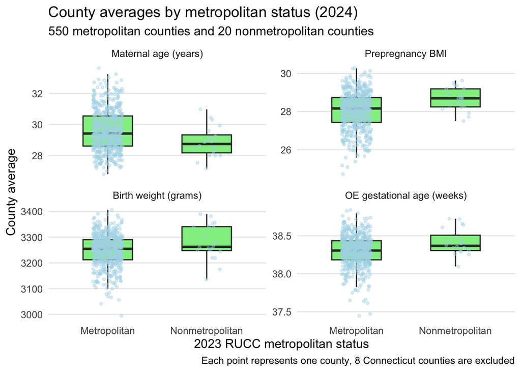

```r
# rurality boxplot

rurality_long <- analysis_data %>%
  filter(!is.na(metro_status)) %>%
  select(
    metro_status,
    maternal_age,
    prepregnancy_bmi,
    birth_weight_g,
    gestational_age_oe_weeks
  ) %>%
  pivot_longer(
    cols = -metro_status,
    names_to = "measure",
    values_to = "county_average"
  ) %>%
  mutate(
    measure = factor(
      measure,
      levels = c(
        "maternal_age",
        "prepregnancy_bmi",
        "birth_weight_g",
        "gestational_age_oe_weeks"
      ),
      labels = c(
        "Maternal age (years)",
        "Prepregnancy BMI",
        "Birth weight (grams)",
        "OE gestational age (weeks)"
      )
    )
  )

rurality_plot <- ggplot(
  rurality_long,
  aes(x = metro_status, y = county_average)
) +
  geom_boxplot(
    width = 0.5,
    fill = "lightgreen",
    outlier.shape = NA
  ) +
  geom_point(
    position = position_jitter(
      width = 0.15,
      height = 0,
      seed = 181
    ),
    color = "lightblue",
    alpha = 0.4,
    size = 1
  ) +
  facet_wrap(
    ~ measure,
    scales = "free_y",
    ncol = 2
  ) +
  labs(
    title = "County averages by metropolitan status (2024)",
    subtitle = "550 metropolitan counties and 20 nonmetropolitan counties",
    x = "2023 RUCC metropolitan status",
    y = "County average",
    caption = "Each point represents one county, 8 Connecticut counties are excluded"
  ) +
  theme_minimal(base_size = 12) +
  theme(
    panel.grid.major.x = element_blank(),
    panel.grid.minor = element_blank()
  )

print(rurality_plot)
```

## 1.2: Identify counties with relatively low or high average birth weight and gestational age, defined as values at or below the 10th percentile or at or above the 90th percentile among included counties. Use labeled plots to display these counties and describe their regional and rurality distributions

```r
# reginal birth-weighting comparison table

regional_weighted_summary <- analysis_data %>%
  select(
    region,
    births,
    maternal_age,
    prepregnancy_bmi,
    birth_weight_g,
    gestational_age_oe_weeks
  ) %>%
  pivot_longer(
    cols = c(
      maternal_age,
      prepregnancy_bmi,
      birth_weight_g,
      gestational_age_oe_weeks
    ),
    names_to = "measure",
    values_to = "county_average"
  ) %>%
  group_by(region, measure) %>%
  summarise(
    n_counties = n(),
    total_births = sum(births),
    unweighted_mean = mean(county_average),
    birth_weighted_mean = weighted.mean(
      county_average,
      w = births
    ),
    .groups = "drop"
  ) %>%
  mutate(
    difference = birth_weighted_mean - unweighted_mean
  )

print(regional_weighted_summary, n = Inf, width = Inf)
```

```
## # A tibble: 16 × 7
##    region    measure                  n_counties total_births unweighted_mean
##    <fct>     <chr>                         <int>        <dbl>           <dbl>
##  1 Northeast birth_weight_g                  110       530988          3274.
##  2 Northeast gestational_age_oe_weeks        110       530988            38.4
##  3 Northeast maternal_age                    110       530988            30.6
##  4 Northeast prepregnancy_bmi                110       530988            27.8
##  5 Midwest   birth_weight_g                  137       510270          3267.
##  6 Midwest   gestational_age_oe_weeks        137       510270            38.3
##  7 Midwest   maternal_age                    137       510270            29.4
##  8 Midwest   prepregnancy_bmi                137       510270            28.3
##  9 South     birth_weight_g                  232      1098803          3222.
## 10 South     gestational_age_oe_weeks        232      1098803            38.2
## 11 South     maternal_age                    232      1098803            29.2
## 12 South     prepregnancy_bmi                232      1098803            28.2
```

[output cut: 22 more lines]

```r
# rurality birth-weighting comparison table
aim1_vars <- c(
  "maternal_age",
  "prepregnancy_bmi",
  "birth_weight_g",
  "gestational_age_oe_weeks"
)

rurality_weighted_summary <- analysis_data %>%
  filter(!is.na(metro_status)) %>%
  select(metro_status, births, all_of(aim1_vars)) %>%
  pivot_longer(
    cols = all_of(aim1_vars),
    names_to = "measure",
    values_to = "county_average"
  ) %>%
  group_by(metro_status, measure) %>%
  summarise(
    n_counties = n(),
    total_births = sum(births),
    unweighted_mean = mean(county_average),
    birth_weighted_mean = weighted.mean(
      county_average,
      w = births
    ),
    .groups = "drop"
  ) %>%
  mutate(
    difference = birth_weighted_mean - unweighted_mean
  )

print(rurality_weighted_summary, n = Inf, width = Inf)
```

```
## # A tibble: 8 × 7
##   metro_status    measure                  n_counties total_births
##   <fct>           <chr>                         <int>        <dbl>
## 1 Metropolitan    birth_weight_g                  550      2820358
## 2 Metropolitan    gestational_age_oe_weeks        550      2820358
## 3 Metropolitan    maternal_age                    550      2820358
## 4 Metropolitan    prepregnancy_bmi                550      2820358
## 5 Nonmetropolitan birth_weight_g                   20        26428
## 6 Nonmetropolitan gestational_age_oe_weeks         20        26428
## 7 Nonmetropolitan maternal_age                     20        26428
## 8 Nonmetropolitan prepregnancy_bmi                 20        26428
##   unweighted_mean birth_weighted_mean difference
##             <dbl>               <dbl>      <dbl>
## 1          3249.               3238.   -11.3
## 2            38.3                38.3    0.0203
## 3            29.6                30.1    0.438
## 4            28.0                27.7   -0.347
## 5          3281.               3271.   -10.3
## 6            38.4                38.4   -0.0171
## 7            28.9                28.9    0.00335
## 8            28.7                28.6   -0.0340
```

```r
# identifying counties with relatively low or high birth weight and gestational age
aim1_cutoffs <- analysis_data %>%
  summarise(
    birth_weight_p10 = quantile(
      birth_weight_g, 0.10, names = FALSE
    ),
    birth_weight_p90 = quantile(
      birth_weight_g, 0.90, names = FALSE
    ),
    gestational_age_p10 = quantile(
      gestational_age_oe_weeks, 0.10, names = FALSE
    ),
    gestational_age_p90 = quantile(
      gestational_age_oe_weeks, 0.90, names = FALSE
    )
  )

print(as.data.frame(aim1_cutoffs), row.names = FALSE)
```

```
##  birth_weight_p10 birth_weight_p90 gestational_age_p10 gestational_age_p90
##          3167.701         3322.601              38.065              38.556
```

```r
aim1_county_groups <- analysis_data %>%
  mutate(
    birth_weight_group = case_when(
      birth_weight_g <= aim1_cutoffs$birth_weight_p10 ~
        "Relatively low",
      birth_weight_g >= aim1_cutoffs$birth_weight_p90 ~
        "Relatively high",
      TRUE ~ "Middle"
    ),

    gestational_age_group = case_when(
      gestational_age_oe_weeks <=
        aim1_cutoffs$gestational_age_p10 ~ "Relatively low",
      gestational_age_oe_weeks >=
        aim1_cutoffs$gestational_age_p90 ~ "Relatively high",
      TRUE ~ "Middle"
    )
  ) %>%
  mutate(
    across(
      c(birth_weight_group, gestational_age_group),
      ~ factor(
        .x,
        levels = c("Relatively low", "Middle", "Relatively high")
      )
    )
  )

print(
  aim1_county_groups %>%
    count(birth_weight_group, .drop = FALSE)
)
```

```
## # A tibble: 3 × 2
##   birth_weight_group     n
##   <fct>              <int>
## 1 Relatively low        58
## 2 Middle               462
## 3 Relatively high       58
```

```r
print(
  aim1_county_groups %>%
    count(gestational_age_group, .drop = FALSE)
)
```

```
## # A tibble: 3 × 2
##   gestational_age_group     n
##   <fct>                 <int>
## 1 Relatively low           59
## 2 Middle                  460
## 3 Relatively high          59
```

```r
aim1_county_groups <- analysis_data %>%
  mutate(
    birth_weight_group = case_when(
      birth_weight_g <= aim1_cutoffs$birth_weight_p10 ~
        "Relatively low",
      birth_weight_g >= aim1_cutoffs$birth_weight_p90 ~
        "Relatively high",
      TRUE ~ "Middle"
    ),

    gestational_age_group = case_when(
      gestational_age_oe_weeks <=
        aim1_cutoffs$gestational_age_p10 ~ "Relatively low",
      gestational_age_oe_weeks >=
        aim1_cutoffs$gestational_age_p90 ~ "Relatively high",
      TRUE ~ "Middle"
    )
  ) %>%
  mutate(
    across(
      c(birth_weight_group, gestational_age_group),
      ~ factor(
        .x,
        levels = c("Relatively low", "Middle", "Relatively high")
      )
    )
  )

print(
  aim1_county_groups %>%
    count(birth_weight_group, .drop = FALSE)
)
```

```
## # A tibble: 3 × 2
##   birth_weight_group     n
##   <fct>              <int>
## 1 Relatively low        58
## 2 Middle               462
## 3 Relatively high       58
```

```r
print(
  aim1_county_groups %>%
    count(gestational_age_group, .drop = FALSE)
)
```

```
## # A tibble: 3 × 2
##   gestational_age_group     n
##   <fct>                 <int>
## 1 Relatively low           59
## 2 Middle                  460
## 3 Relatively high          59
```

# draw the map

```r
options(tigris_use_cache = TRUE)
county_boundaries <- tigris::counties(
  cb = TRUE,
  resolution = "20m",
  year = 2021
) %>%
  filter(as.integer(STATEFP) <= 56)
map_unmatched <- aim1_county_groups %>%
  anti_join(
    county_boundaries %>%
      st_drop_geometry() %>%
      select(GEOID),
    by = c("county_fips" = "GEOID")
  ) %>%
  select(county, county_fips)

print(map_unmatched, n = Inf)
```

```
## # A tibble: 0 × 2
## # ℹ 2 variables: county <chr>, county_fips <chr>
```

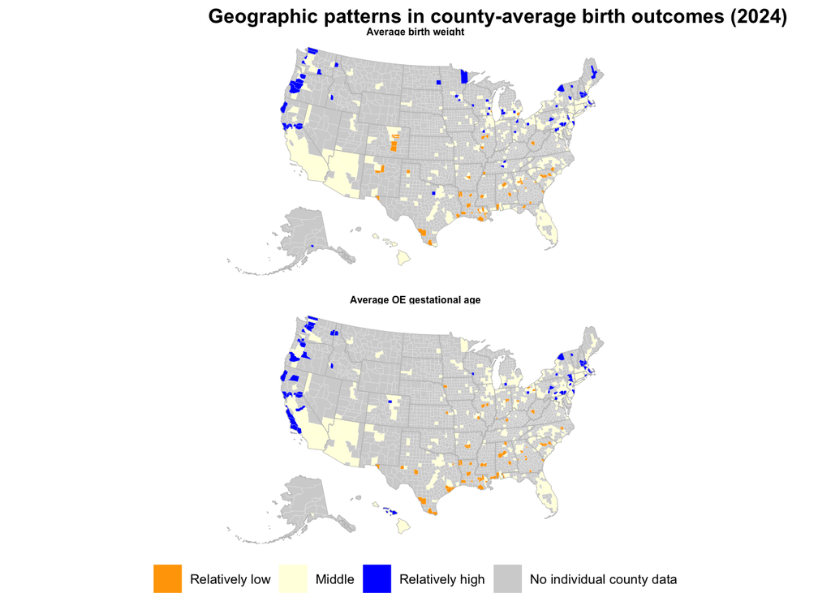

```r
county_map_data <- county_boundaries %>%
  select(GEOID, STATEFP) %>%
  left_join(
    aim1_county_groups %>%
      select(
        county_fips,
        birth_weight_group,
        gestational_age_group
      ),
    by = c("GEOID" = "county_fips")
  ) %>%
  tigris::shift_geometry(
    geoid_column = "GEOID",
    preserve_area = FALSE
  )

state_borders <- county_map_data %>%
  group_by(STATEFP) %>%
  summarise(.groups = "drop")

map_panels <- bind_rows(
  county_map_data %>%
    mutate(
      outcome = "Average birth weight",
      category = as.character(birth_weight_group)
    ),
  county_map_data %>%
    mutate(
      outcome = "Average OE gestational age",
      category = as.character(gestational_age_group)
    )
) %>%
  mutate(
    category = replace_na(
      category,
      "No individual county data"
    ),
    category = factor(
      category,
      levels = c(
        "Relatively low",
        "Middle",
        "Relatively high",
        "No individual county data"
      )
    )
  )


aim1_map <- ggplot(map_panels) +
  geom_sf(
    aes(fill = category),
    color = "white",
    linewidth = 0.03
  ) +
  geom_sf(
    data = state_borders,
    fill = NA,
    color = "gray",
    linewidth = 0.15
  ) +
  facet_wrap(~ outcome, ncol = 1) +
  scale_fill_manual(
    values = c(
      "Relatively low" = "orange",
      "Middle" = "lightyellow",
      "Relatively high" = "blue",
      "No individual county data" = "lightgray"
    ),
    drop = FALSE,
    name = NULL
  ) +
  coord_sf(datum = NA) +
  labs(
    title = "Geographic patterns in county-average birth outcomes (2024)"
  ) +
  theme_void(base_size = 10) +
  theme(
    legend.position = "bottom",
    strip.text = element_text(face = "bold", size = 6),
    plot.title = element_text(face = "bold"),
    plot.caption = element_text(hjust = 0)
  )
## Counties with fewer than 100000 residents are pooled within states in the source data and cannot be mapped individually. Colored counties represent the 578 individually identified counties
print(aim1_map)
```

# Aim 2. Explore county-level relationships between prenatal visits, maternal characteristics, and birth outcomes in 2024

## 2.1: Use scatterplots to examine associations between average prenatal visits and average birth weight and obstetric-estimate gestational age. Compare patterns across Census regions and, where sample sizes permit, metropolitan and nonmetropolitan counties

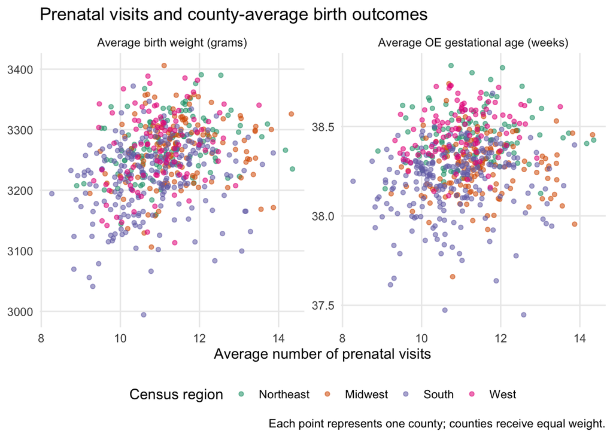

```r
aim2_scatter_data <- analysis_data %>%
  select(
    county,
    region,
    prenatal_visits,
    birth_weight_g,
    gestational_age_oe_weeks
  ) %>%
  pivot_longer(
    cols = c(
      birth_weight_g,
      gestational_age_oe_weeks
    ),
    names_to = "outcome",
    values_to = "county_average"
  ) %>%
  mutate(
    outcome = factor(
      outcome,
      levels = c(
        "birth_weight_g",
        "gestational_age_oe_weeks"
      ),
      labels = c(
        "Average birth weight (grams)",
        "Average OE gestational age (weeks)"
      )
    )
  )

prenatal_scatter_plot <- ggplot(
  aim2_scatter_data,
  aes(
    x = prenatal_visits,
    y = county_average,
    color = region
  )
) +
  geom_point(alpha = 0.55, size = 1.4) +
  facet_wrap(
    ~ outcome,
    scales = "free_y",
    ncol = 2
  ) +
  scale_color_brewer(palette = "Dark2") +
  labs(
    title = "Prenatal visits and county-average birth outcomes",
    x = "Average number of prenatal visits",
    y = NULL,
    color = "Census region",
    caption = "Each point represents one county; counties receive equal weight."
  ) +
  theme_minimal(base_size = 12) +
  theme(
    legend.position = "bottom",
    panel.grid.minor = element_blank()
  )

print(prenatal_scatter_plot)
```

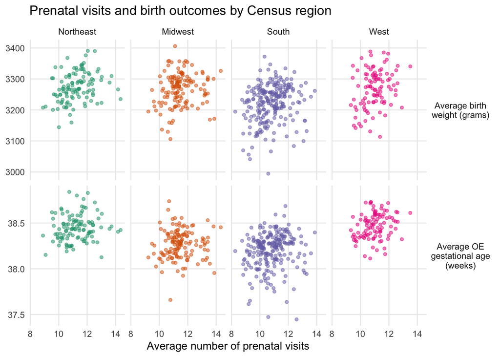

```r
# seperate plots
regional_prenatal_plot <- ggplot(
  aim2_scatter_data,
  aes(
    x = prenatal_visits,
    y = county_average,
    color = region
  )
) +
  geom_point(alpha = 0.5, size = 1.2) +
  facet_grid(
    outcome ~ region,
    scales = "free_y",
    labeller = label_wrap_gen(width = 18)
  ) +
  scale_color_brewer(palette = "Dark2") +
  labs(
    title = "Prenatal visits and birth outcomes by Census region",
    x = "Average number of prenatal visits",
    y = NULL
  ) +
  theme_minimal(base_size = 11) +
  theme(
    legend.position = "none",
    panel.grid.minor = element_blank(),
    strip.text.y = element_text(angle = 0)
  )

print(regional_prenatal_plot)
```

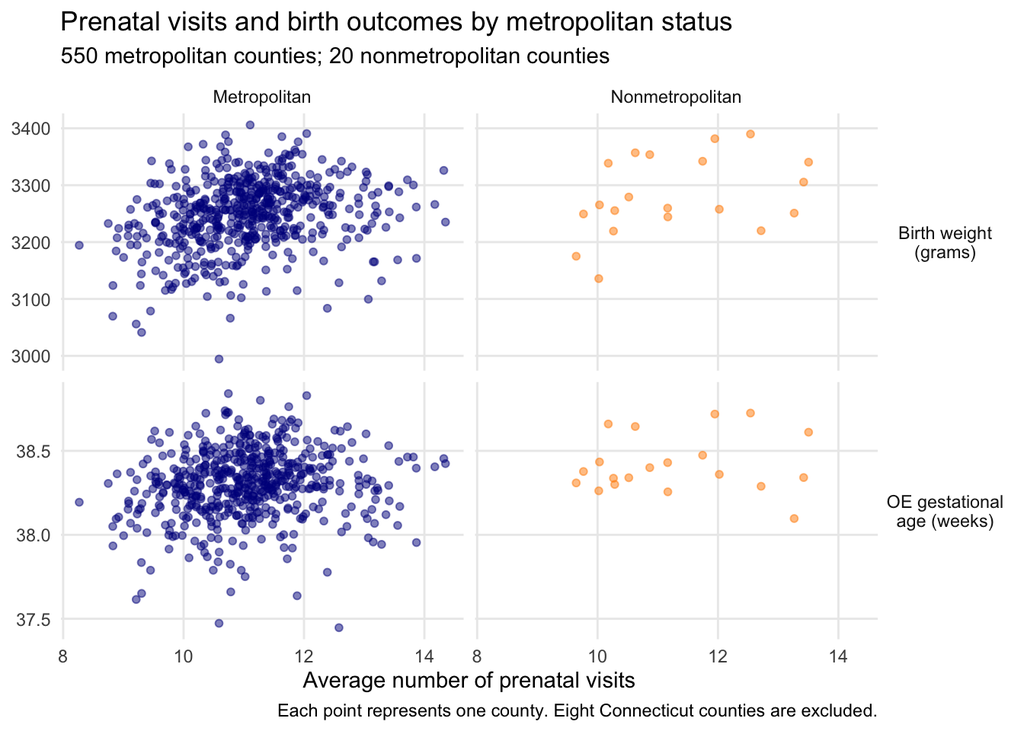

```r
# rurality comparison
rurality_scatter_data <- analysis_data %>%
  filter(!is.na(metro_status)) %>%
  select(
    metro_status,
    prenatal_visits,
    birth_weight_g,
    gestational_age_oe_weeks
  ) %>%
  pivot_longer(
    cols = c(
      birth_weight_g,
      gestational_age_oe_weeks
    ),
    names_to = "outcome",
    values_to = "county_average"
  )

rurality_prenatal_plot <- ggplot(
  rurality_scatter_data,
  aes(
    x = prenatal_visits,
    y = county_average,
    color = metro_status
  )
) +
  geom_point(alpha = 0.5, size = 1.4) +
  facet_grid(
    outcome ~ metro_status,
    scales = "free_y",
    labeller = labeller(
      outcome = c(
        birth_weight_g = "Birth weight\n(grams)",
        gestational_age_oe_weeks = "OE gestational\nage (weeks)"
      )
    )
  ) +
  scale_color_manual(
    values = c(
      "Metropolitan" = "darkblue",
      "Nonmetropolitan" = "darkorange"
    )
  ) +
  labs(
    title = "Prenatal visits and birth outcomes by metropolitan status",
    subtitle = "550 metropolitan counties; 20 nonmetropolitan counties",
    x = "Average number of prenatal visits",
    y = NULL,
    caption = "Each point represents one county. Eight Connecticut counties are excluded."
  ) +
  theme_minimal(base_size = 11) +
  theme(
    legend.position = "none",
    panel.grid.minor = element_blank(),
    strip.text.y = element_text(angle = 0)
  )

print(rurality_prenatal_plot)
```

## 2.2: Divide counties into lower, middle, and upper thirds based on average prenatal visits. Compare maternal age, prepregnancy BMI, birth weight, and gestational age across these groups using summary tables and boxplots. Use the same group cutoffs across regions to examine whether differences are consistent within regions.

```r
prenatal_cutoffs <- analysis_data %>%
  summarise(
    lower_cutoff = quantile(
      prenatal_visits, 1 / 3, names = FALSE
    ),
    upper_cutoff = quantile(
      prenatal_visits, 2 / 3, names = FALSE
    )
  )

print(as.data.frame(prenatal_cutoffs), row.names = FALSE)
```

```
##  lower_cutoff upper_cutoff
##        10.604     11.42867
```

```r
aim2_data <- analysis_data %>%
  mutate(
    prenatal_group = factor(
      case_when(
        prenatal_visits <= prenatal_cutoffs$lower_cutoff ~
          "Lower third",
        prenatal_visits <= prenatal_cutoffs$upper_cutoff ~
          "Middle third",
        TRUE ~ "Upper third"
      ),
      levels = c(
        "Lower third",
        "Middle third",
        "Upper third"
      )
    )
  )

prenatal_group_check <- aim2_data %>%
  group_by(prenatal_group) %>%
  summarise(
    n_counties = n(),
    min_visits = min(prenatal_visits),
    max_visits = max(prenatal_visits),
    .groups = "drop"
  )

print(prenatal_group_check, width = Inf)
```

```
## # A tibble: 3 × 4
##   prenatal_group n_counties min_visits max_visits
##   <fct>               <int>      <dbl>      <dbl>
## 1 Lower third           193       8.27       10.6
## 2 Middle third          192      10.6        11.4
## 3 Upper third           193      11.4        14.4
```

```r
#comaprison table
aim2_group_summary <- aim2_data %>%
  select(
    prenatal_group,
    maternal_age,
    prepregnancy_bmi,
    birth_weight_g,
    gestational_age_oe_weeks
  ) %>%
  pivot_longer(
    cols = -prenatal_group,
    names_to = "measure",
    values_to = "county_average"
  ) %>%
  group_by(prenatal_group, measure) %>%
  summarise(
    n_counties = n(),
    mean = mean(county_average),
    sd = sd(county_average),
    median = median(county_average),
    q1 = quantile(county_average, 0.25, names = FALSE),
    q3 = quantile(county_average, 0.75, names = FALSE),
    .groups = "drop"
  )

print(aim2_group_summary, n = Inf, width = Inf)
```

```
## # A tibble: 12 × 8
##    prenatal_group measure                  n_counties   mean     sd median
##    <fct>          <chr>                         <int>  <dbl>  <dbl>  <dbl>
##  1 Lower third    birth_weight_g                  193 3222.  61.9   3226.
##  2 Lower third    gestational_age_oe_weeks        193   38.2  0.200   38.3
##  3 Lower third    maternal_age                    193   29.2  1.24    29.2
##  4 Lower third    prepregnancy_bmi                193   28.1  0.951   28.2
##  5 Middle third   birth_weight_g                  192 3261.  54.6   3266.
##  6 Middle third   gestational_age_oe_weeks        192   38.3  0.188   38.3
##  7 Middle third   maternal_age                    192   29.8  1.34    29.5
##  8 Middle third   prepregnancy_bmi                192   28.0  0.965   28.2
##  9 Upper third    birth_weight_g                  193 3268.  55.2   3273.
## 10 Upper third    gestational_age_oe_weeks        193   38.3  0.205   38.4
## 11 Upper third    maternal_age                    193   29.8  1.28    29.7
## 12 Upper third    prepregnancy_bmi                193   28.0  0.955   28.1
##        q1     q3
##     <dbl>  <dbl>
##  1 3188.  3260.
##  2   38.1   38.4
##  3   28.3   29.9
##  4   27.6   28.8
##  5 3230.  3296.
##  6   38.2   38.5
##  7   28.8   30.7
##  8   27.3   28.7
##  9 3229.  3301.
## 10   38.2   38.5
## 11   28.8   30.8
## 12   27.4   28.7
```

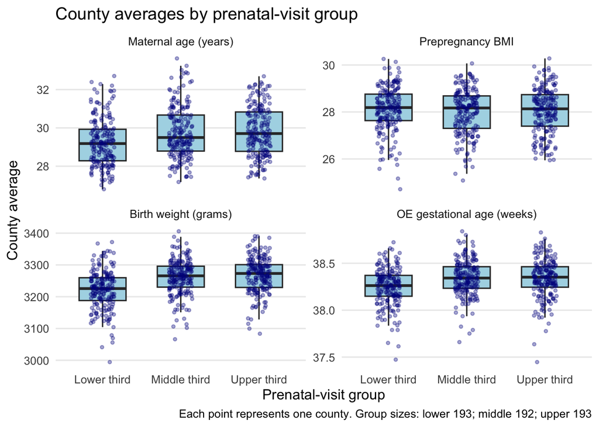

```r
#plot by perinatal visit
aim2_group_long <- aim2_data %>%
  select(
    prenatal_group,
    maternal_age,
    prepregnancy_bmi,
    birth_weight_g,
    gestational_age_oe_weeks
  ) %>%
  pivot_longer(
    cols = -prenatal_group,
    names_to = "measure",
    values_to = "county_average"
  ) %>%
  mutate(
    measure = factor(
      measure,
      levels = c(
        "maternal_age",
        "prepregnancy_bmi",
        "birth_weight_g",
        "gestational_age_oe_weeks"
      ),
      labels = c(
        "Maternal age (years)",
        "Prepregnancy BMI",
        "Birth weight (grams)",
        "OE gestational age (weeks)"
      )
    )
  )

prenatal_group_plot <- ggplot(
  aim2_group_long,
  aes(x = prenatal_group, y = county_average)
) +
  geom_boxplot(
    width = 0.6,
    fill = "lightblue",
    outlier.shape = NA
  ) +
  geom_point(
    position = position_jitter(
      width = 0.15,
      height = 0,
      seed = 181
    ),
    alpha = 0.35,
    size = 1,
    color = "darkblue"
  ) +
  facet_wrap(~ measure, scales = "free_y", ncol = 2) +
  labs(
    title = "County averages by prenatal-visit group",
    x = "Prenatal-visit group",
    y = "County average",
    caption = paste(
      "Each point represents one county.",
      "Group sizes: lower 193; middle 192; upper 193"
    )
  ) +
  theme_minimal(base_size = 12) +
  theme(
    panel.grid.major.x = element_blank(),
    panel.grid.minor = element_blank()
  )

print(prenatal_group_plot)
```

```r
# by region
region_group_counts <- aim2_data %>%
  count(
    region,
    prenatal_group,
    .drop = FALSE
  ) %>%
  group_by(region) %>%
  mutate(
    percent_within_region = 100 * n / sum(n)
  ) %>%
  ungroup()

print(region_group_counts, n = Inf, width = Inf)
```

```
## # A tibble: 12 × 4
##    region    prenatal_group     n percent_within_region
##    <fct>     <fct>          <int>                 <dbl>
##  1 Northeast Lower third       33                  30
##  2 Northeast Middle third      32                  29.1
##  3 Northeast Upper third       45                  40.9
##  4 Midwest   Lower third       21                  15.3
##  5 Midwest   Middle third      57                  41.6
##  6 Midwest   Upper third       59                  43.1
##  7 South     Lower third      107                  46.1
##  8 South     Middle third      63                  27.2
##  9 South     Upper third       62                  26.7
## 10 West      Lower third       32                  32.3
## 11 West      Middle third      40                  40.4
## 12 West      Upper third       27                  27.3
```

```r
#compare group means by region
region_group_summary <- aim2_data %>%
  group_by(region, prenatal_group) %>%
  summarise(
    n_counties = n(),
    mean_maternal_age = mean(maternal_age),
    mean_bmi = mean(prepregnancy_bmi),
    mean_birth_weight_g = mean(birth_weight_g),
    mean_ga_weeks = mean(gestational_age_oe_weeks),
    .groups = "drop"
  )

print(region_group_summary, n = Inf, width = Inf)
```

```
## # A tibble: 12 × 7
##    region    prenatal_group n_counties mean_maternal_age mean_bmi
##    <fct>     <fct>               <int>             <dbl>    <dbl>
##  1 Northeast Lower third            33              30.2     27.9
##  2 Northeast Middle third           32              30.7     27.6
##  3 Northeast Upper third            45              30.7     27.8
##  4 Midwest   Lower third            21              29.0     28.6
##  5 Midwest   Middle third           57              29.4     28.2
##  6 Midwest   Upper third            59              29.5     28.3
##  7 South     Lower third           107              28.9     28.2
##  8 South     Middle third           63              29.3     28.2
##  9 South     Upper third            62              29.4     28.1
## 10 West      Lower third            32              29.6     27.8
## 11 West      Middle third           40              30.1     27.7
## 12 West      Upper third            27              29.9     27.7
##    mean_birth_weight_g mean_ga_weeks
##                  <dbl>         <dbl>
##  1               3248.          38.4
##  2               3272.          38.5
##  3               3293.          38.5
##  4               3232.          38.2
##  5               3271.          38.3
##  6               3275.          38.3
##  7               3205.          38.2
##  8               3238.          38.2
##  9               3236.          38.2
## 10               3242.          38.4
## 11               3276.          38.5
## 12               3287.          38.5
```

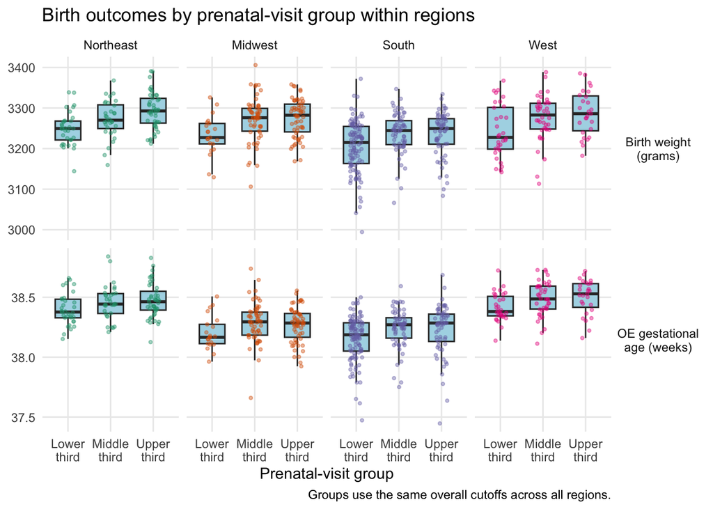

```r
# plot birth outcomes by region
aim2_region_long <- aim2_data %>%
  select(
    region,
    prenatal_group,
    birth_weight_g,
    gestational_age_oe_weeks
  ) %>%
  pivot_longer(
    cols = c(
      birth_weight_g,
      gestational_age_oe_weeks
    ),
    names_to = "outcome",
    values_to = "county_average"
  ) %>%
  mutate(
    outcome = factor(
      outcome,
      levels = c(
        "birth_weight_g",
        "gestational_age_oe_weeks"
      ),
      labels = c(
        "Birth weight\n(grams)",
        "OE gestational\nage (weeks)"
      )
    )
  )

region_group_plot <- ggplot(
  aim2_region_long,
  aes(x = prenatal_group, y = county_average)
) +
  geom_boxplot(
    fill = "lightblue",
    width = 0.6,
    outlier.shape = NA
  ) +
  geom_point(
    aes(color = region),
    position = position_jitter(
      width = 0.15,
      height = 0,
      seed = 181
    ),
    alpha = 0.4,
    size = 0.8
  ) +
  facet_grid(outcome ~ region, scales = "free_y") +
  scale_color_brewer(palette = "Dark2") +
  scale_x_discrete(
    labels = c(
      "Lower third" = "Lower\nthird",
      "Middle third" = "Middle\nthird",
      "Upper third" = "Upper\nthird"
    )
  ) +
  labs(
    title = "Birth outcomes by prenatal-visit group within regions",
    x = "Prenatal-visit group",
    y = NULL,
    caption = "Groups use the same overall cutoffs across all regions."
  ) +
  theme_minimal(base_size = 11) +
  theme(
    legend.position = "none",
    panel.grid.minor = element_blank(),
    strip.text.y = element_text(angle = 0)
  )

print(region_group_plot)
```

```r
gestational_age_detail <- region_group_summary %>%
  select(
    region,
    prenatal_group,
    n_counties,
    mean_ga_weeks
  ) %>%
  mutate(
    mean_ga_weeks = sprintf("%.3f", mean_ga_weeks)
  )

print(gestational_age_detail, n = Inf)
```

```
## # A tibble: 12 × 4
##    region    prenatal_group n_counties mean_ga_weeks
##    <fct>     <fct>               <int> <chr>
##  1 Northeast Lower third            33 38.400
##  2 Northeast Middle third           32 38.458
##  3 Northeast Upper third            45 38.473
##  4 Midwest   Lower third            21 38.204
##  5 Midwest   Middle third           57 38.290
##  6 Midwest   Upper third            59 38.269
##  7 South     Lower third           107 38.155
##  8 South     Middle third           63 38.242
##  9 South     Upper third            62 38.228
## 10 West      Lower third            32 38.415
## 11 West      Middle third           40 38.488
## 12 West      Upper third            27 38.501
```

# save everything in local file

```r
output_root <- paste0(
  "/Users/hellarinewu/Desktop/QBS 181 Data Wrangling/",
  "project_outputs"
)

save_aim_outputs <- function(aim_name, data, tables, plots) {

  aim_dir <- file.path(output_root, aim_name)
  dir.create(aim_dir, recursive = TRUE, showWarnings = FALSE)
  saveRDS(
    list(data = data, tables = tables),
    file = file.path(aim_dir, paste0(aim_name, "_results.rds"))
  )
  for (table_name in names(tables)) {
    write.csv(
      tables[[table_name]],
      file = file.path(aim_dir, paste0(table_name, ".csv")),
      row.names = FALSE
    )
  }
  for (plot_name in names(plots)) {
    ggsave(
      filename = file.path(aim_dir, paste0(plot_name, ".png")),
      plot = plots[[plot_name]],
      width = 14,
      height = if (plot_name == "county_maps") 12 else 8,
      units = "in",
      dpi = 300,
      bg = "white"
    )
  }
}

#aim 1
aim1_tables <- list(
  regional_summary = regional_summary,
  rurality_summary = rurality_summary,
  rurality_by_region = rurality_by_region,
  regional_weighted_summary = regional_weighted_summary,
  rurality_weighted_summary = rurality_weighted_summary,
  percentile_cutoffs = aim1_cutoffs,
  birth_weight_group_counts = aim1_county_groups %>%
    count(birth_weight_group, .drop = FALSE),
  gestational_age_group_counts = aim1_county_groups %>%
    count(gestational_age_group, .drop = FALSE)
)
if (exists("region_tail_summary")) {
  aim1_tables$region_tail_summary <- region_tail_summary
}

aim1_plots <- list(
  regional_boxplots = regional_plot,
  rurality_boxplots = rurality_plot,
  county_maps = aim1_map
)

save_aim_outputs(
  aim_name = "aim1",
  data = aim1_county_groups,
  tables = aim1_tables,
  plots = aim1_plots
)

#aim 2
aim2_tables <- list(
  prenatal_cutoffs = prenatal_cutoffs,
  prenatal_group_check = prenatal_group_check,
  prenatal_group_summary = aim2_group_summary,
  region_group_counts = region_group_counts,
  region_group_summary = region_group_summary,
  gestational_age_detail = gestational_age_detail
)

aim2_plots <- list(
  overall_scatter = prenatal_scatter_plot,
  regional_scatter = regional_prenatal_plot,
  rurality_scatter = rurality_prenatal_plot,
  prenatal_group_boxplots = prenatal_group_plot,
  regional_group_boxplots = region_group_plot
)

save_aim_outputs(
  aim_name = "aim2",
  data = aim2_data,
  tables = aim2_tables,
  plots = aim2_plots
)


list.files(output_root, recursive = TRUE)
```

```
##  [1] "aim1/aim1_results.rds"
##  [2] "aim1/birth_weight_group_counts.csv"
##  [3] "aim1/county_maps.png"
##  [4] "aim1/gestational_age_group_counts.csv"
##  [5] "aim1/percentile_cutoffs.csv"
##  [6] "aim1/regional_boxplots.png"
##  [7] "aim1/regional_summary.csv"
##  [8] "aim1/regional_weighted_summary.csv"
##  [9] "aim1/rurality_boxplots.png"
## [10] "aim1/rurality_by_region.csv"
## [11] "aim1/rurality_summary.csv"
## [12] "aim1/rurality_weighted_summary.csv"
## [13] "aim2/aim2_results.rds"
## [14] "aim2/gestational_age_detail.csv"
## [15] "aim2/overall_scatter.png"
## [16] "aim2/prenatal_cutoffs.csv"
## [17] "aim2/prenatal_group_boxplots.png"
## [18] "aim2/prenatal_group_check.csv"
## [19] "aim2/prenatal_group_summary.csv"
## [20] "aim2/region_group_counts.csv"
## [21] "aim2/region_group_summary.csv"
## [22] "aim2/regional_group_boxplots.png"
## [23] "aim2/regional_scatter.png"
## [24] "aim2/rurality_scatter.png"
```